# BANA 7050 Time series and forecasting

## Section 4

### FORECASTS

Naive forecasting is basically taking the last value in our data to predict our next value. Naive forecasts work for data when there is no presence of seasonality but considering that there is seasonality in our data we are better off using a Seasonal naive forecast to get a more accurate forecast. The forecasts below are made for the next 6 periods as in 6 months in our case.

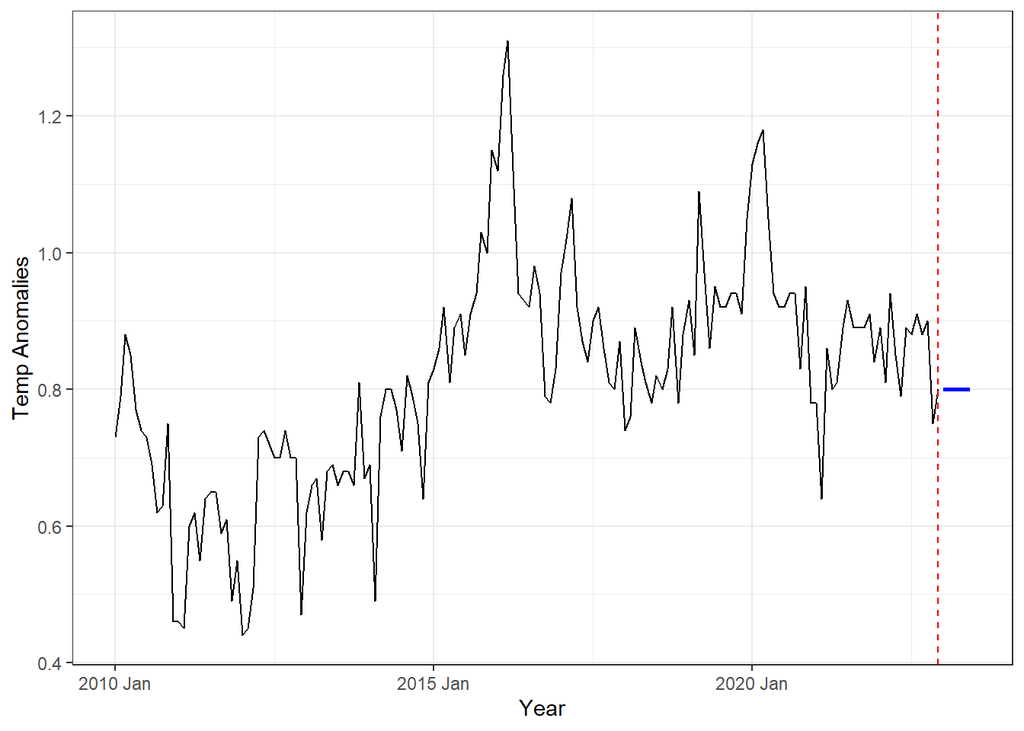

```r
data_monthly %>%
  mutate(Year = yearmonth(Year)) %>%
          as_tsibble(index = Year) %>%
  model(
    Naive = NAIVE(Value)
  ) %>%
  forecast(h = 6) %>%
  autoplot(data_monthly, level = NULL,size=1) +
  geom_vline(aes(xintercept = ymd("2022-12-01")), color = "red", linetype = "dashed") +
  theme_bw()+
  ylab('Temp Anomalies')
```

Seasonal data seems to work well with our data as it takes seasonality into account while forecasting our value and since temperature anomalies are unpredictable this could be useful.

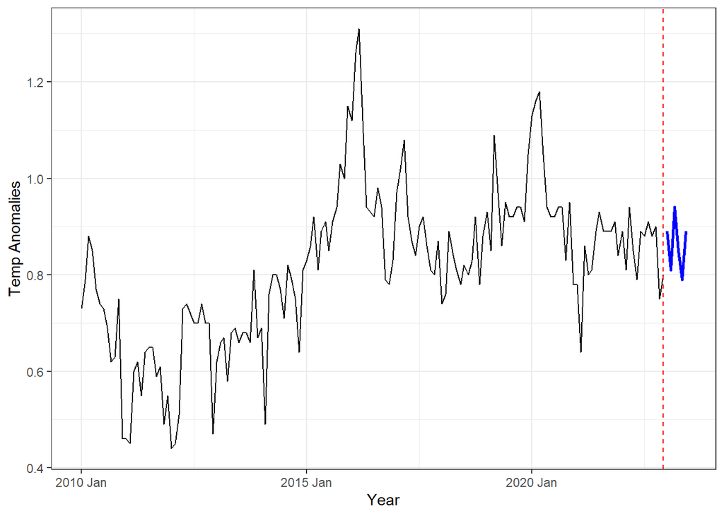

```r
data_monthly %>%
  mutate(Year = yearmonth(Year)) %>%
          as_tsibble(index = Year) %>%
  model(
    Naive = SNAIVE(Value)
  ) %>%
  forecast(h = 6) %>%
  autoplot(data_monthly, level = NULL,size=1) +
  geom_vline(aes(xintercept = ymd("2022-12-01")), color = "red", linetype = "dashed") +
  theme_bw()+
  ylab('Temp Anomalies')
```